# Assignment 3 Task 1 - ESM 244

Author

Julia S. Cox

# 1 Classifying Palmetto species using BLR

## 1.1 Overview

The data explored in this report concerns measurements and physical attributes of two species of Palmetto at the Archbold Biological Station in south-central Florida. Traits such as height, canopy length, canopy width, and number of green leaves were recorded for both Serenoa repens and Sabal etonia between 1981 and 2017. These Palmettos were also measured across different habitats, although we will not be considering habitat in this summary. The objective of this report is to use Binary Logistic Regression (BLR) to automatically classify these species based on their attributes, implement cross-validation and receiver operating characteristic (ROC) curves to select the best model, and to assess the success of the model.

The first section explores the data with plots to better understand how the different attributes may differ between the species. Then, two BLR models are compared and one is selected via cross-validation and ROC curve assessment. Finally, the model success is assessed and the percentage of correct classification for each species is reported.

### 1.1.1 Data:

Abrahamson, W.G. 2019. Survival, growth and biomass estimates of two dominant palmetto species of south-central Florida from 1981 - 2017, ongoing at 5-year intervals ver 1. Environmental Data Initiative. https://doi.org/10.6073/pasta/f2f96ec76fbbd4b9db431c79a770c4d5

```r
library(tidyverse)
library(here)
library(broom)
library(ggplot2)
library(readxl)
library(lubridate)
library(ggtext)
library(patchwork)
library(cowplot)
library(tidymodels)
library(hrbrthemes)
library(janitor)
library(reshape2)
```

```r
palmetto_df <- read_csv(here("Data/palmetto.csv"))

palmetto_df <- palmetto_df %>%
  mutate(as.factor(species)) %>%
  mutate(across('species', str_replace, '1', 's_repens')) %>%
  mutate(across('species', str_replace, '2', 's_etonia')) %>%
  mutate(s_repens = case_when(
    endsWith(species, "s") ~ 1,
    endsWith(species, "a") ~ 0)) %>%
  mutate(as.numeric(height)) %>%
  mutate(as.integer(height)) %>%
  clean_names()

#remove infinite values
palmetto_clean <- palmetto_df[is.finite(palmetto_df$height),]
palmetto_clean <- palmetto_df[is.finite(palmetto_df$length),]
palmetto_clean <- palmetto_df[is.finite(palmetto_df$width),]
palmetto_clean <- palmetto_df[is.finite(palmetto_df$green_lvs),]
```

## 1.2 Plots

Based on these exploratory plots, I would expect that canopy length and number of green leaves are the best predictive traits given the differences in means between Palmetto species. I would expect that tree height has the least predictive power out of these traits, given the similar mean height and distribution between the two species.

```r
#height
height <- ggplot(palmetto_clean, aes(height, fill = species)) +
  geom_histogram(bins = 40, color="#e9ecef",
                 alpha=0.6, position = 'identity') +
  scale_fill_manual(labels = c("S. etonia", "S. repens"), values=c("#404080", "#69b3a2")) +
  xlab("Height") +
  theme_ipsum()

#canopy length
length <- ggplot(palmetto_clean, aes(length, fill = species)) +
  geom_histogram(bins = 40, color="#e9ecef",
                 alpha=0.6, position = 'identity') +
  scale_fill_manual(labels = c("S. etonia", "S. repens"), values=c("#404080", "#69b3a2")) +
  xlab("Canopy length") +
  theme_ipsum()

#canopy width
width <- ggplot(palmetto_clean, aes(width, fill = species)) +
  geom_histogram(bins = 40, color="#e9ecef",
                 alpha=0.6, position = 'identity') +
  scale_fill_manual(labels = c("S. etonia", "S. repens"), values=c("#404080", "#69b3a2")) +
  xlab("Canopy width") +
  theme_ipsum()

#green leaves
leaves <- ggplot(palmetto_clean, aes(green_lvs, fill = species)) +
  geom_boxplot() +
  scale_fill_manual(labels = c("S. etonia", "S. repens"), values=c("#404080", "#69b3a2")) +
  xlab("Number of green leaves") +
  theme_ipsum()

leaves <- leaves +
  theme(axis.title.y=element_blank(),
        axis.text.y=element_blank(),
        axis.ticks.y=element_blank())

# Find the means for each variable for the two species
height_mean_sr <- palmetto_clean %>%
  filter(species == "s_repens") %>%
  summarize(mean_size = mean(height))

height_mean_se <- palmetto_clean %>%
  filter(species == "s_etonia") %>%
  summarize(mean_size = mean(height))

length_mean_sr <- palmetto_clean %>%
  filter(species == "s_repens") %>%
  summarize(mean_size = mean(length))

length_mean_se <- palmetto_clean %>%
  filter(species == "s_etonia") %>%
  summarize(mean_size = mean(length))

width_mean_sr <- palmetto_clean %>%
  filter(species == "s_repens") %>%
  summarize(mean_size = mean(width))

width_mean_se <- palmetto_clean %>%
  filter(species == "s_etonia") %>%
  summarize(mean_size = mean(width))

# Add means to each histogram
height_plot <- height + geom_vline(xintercept = height_mean_sr$mean_size, color = "seagreen3") +
  geom_vline(xintercept = height_mean_se$mean_size, color = "purple3") +
  labs(tag = "B")

length_plot <- length + geom_vline(xintercept = length_mean_sr$mean_size, color = "seagreen3") +
  geom_vline(xintercept = length_mean_se$mean_size, color = "purple3") +
  labs(tag = "C")

width_plot <- width + geom_vline(xintercept = width_mean_sr$mean_size, color = "seagreen3") +
  geom_vline(xintercept = width_mean_se$mean_size, color = "purple3") +
  labs(tag = "A")
```

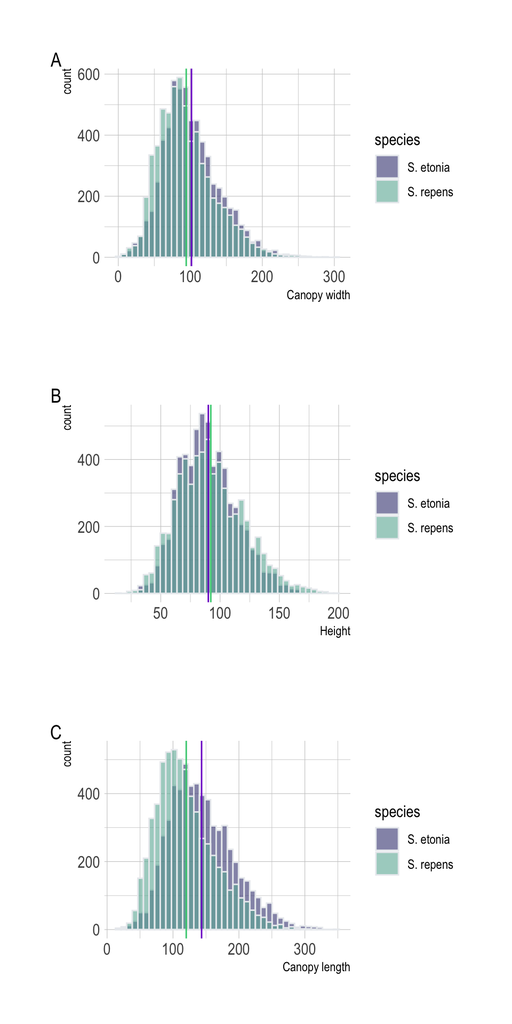

Histograms of distributions of Palmetto attributes. Green and purple lines are means for S. repens and S. etonia, respectively. A: Canopy width histogram. B: Tree height histogram. C: Canopy length hisogram.

```r
#patchwork
width_plot/height_plot/length_plot
```

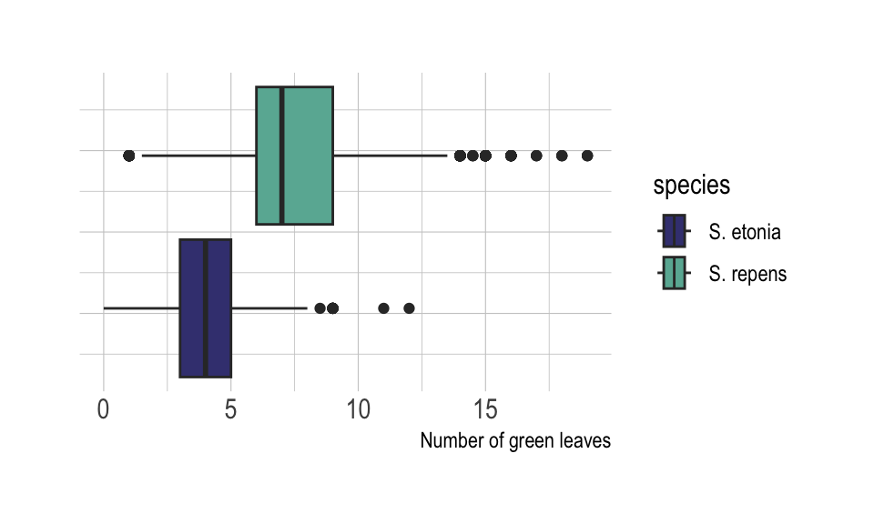

Boxplot of number of green leaves on two Palmetto species.

```r
leaves
```

## 1.3 BLR

Use binary logistic regression to test feasibility of using variables plant height (height), canopy length (length), canopy width (width), and number of green leaves (green_lvs) to classify whether a palmetto is species Serenoa repens or Sabal etonia. We’ll make two models and test their effectiveness.

```r
f1 <- s_repens ~ height + length + width + green_lvs
f2 <- s_repens ~ height + width + green_lvs

blr1 <- glm(formula = f1, data = palmetto_df, family = binomial)
blr2 <- glm(formula = f2, data = palmetto_df, family =binomial)

summary(blr1)
```

```
Call:
glm(formula = f1, family = binomial, data = palmetto_df)

Coefficients:
             Estimate Std. Error z value Pr(>|z|)
(Intercept) -3.226685   0.142071  -22.71   <2e-16 ***
height       0.029217   0.002306   12.67   <2e-16 ***
length      -0.045823   0.001866  -24.56   <2e-16 ***
width       -0.039443   0.002100  -18.78   <2e-16 ***
green_lvs    1.908475   0.038863   49.11   <2e-16 ***
---
Signif. codes:  0 '***' 0.001 '**' 0.01 '*' 0.05 '.' 0.1 ' ' 1

(Dispersion parameter for binomial family taken to be 1)

    Null deviance: 17005.5  on 12266  degrees of freedom
Residual deviance:  5184.6  on 12262  degrees of freedom
  (193 observations deleted due to missingness)
AIC: 5194.6

Number of Fisher Scoring iterations: 7
```

```r
summary(blr2)
```

```
Call:
glm(formula = f2, family = binomial, data = palmetto_df)

Coefficients:
             Estimate Std. Error z value Pr(>|z|)
(Intercept) -3.767722   0.135314 -27.844   <2e-16 ***
height       0.002950   0.001881   1.568    0.117
width       -0.069019   0.001785 -38.661   <2e-16 ***
green_lvs    1.884815   0.036127  52.172   <2e-16 ***
---
Signif. codes:  0 '***' 0.001 '**' 0.01 '*' 0.05 '.' 0.1 ' ' 1

(Dispersion parameter for binomial family taken to be 1)

    Null deviance: 17005.5  on 12266  degrees of freedom
Residual deviance:  5979.5  on 12263  degrees of freedom
  (193 observations deleted due to missingness)
AIC: 5987.5

Number of Fisher Scoring iterations: 7
```

### 1.3.1 Compare the two models using cross-validation

Use repeated cross-validation (10-fold) using tidymodels package. I’ve selected blr1 as the best model.

```r
#convert s_repens to factor
palmetto_clean <- palmetto_clean %>%
  mutate(s_repens = as.factor(s_repens))

set.seed(123)

s_repens_split <- initial_split(palmetto_clean, prop = 0.80, strata = s_repens)
  ### stratified on `s_repens`
s_repens_train_df <- training(s_repens_split)
s_repens_test_df <- testing(s_repens_split)
```

```r
set.seed(10000)
palm_train_folds <- vfold_cv(s_repens_train_df, v = 10)
palm_train_folds
```

```
#  10-fold cross-validation
# A tibble: 10 × 2
   splits             id
   <list>             <chr>
 1 <split [8831/982]> Fold01
 2 <split [8831/982]> Fold02
 3 <split [8831/982]> Fold03
 4 <split [8832/981]> Fold04
 5 <split [8832/981]> Fold05
 6 <split [8832/981]> Fold06
 7 <split [8832/981]> Fold07
 8 <split [8832/981]> Fold08
 9 <split [8832/981]> Fold09
10 <split [8832/981]> Fold10
```

Create a workflow

```r
s_repens_train_df <- s_repens_train_df %>%
  mutate(s_repens = factor(s_repens))

blr_mdl <- logistic_reg() %>%
  set_engine('glm')


blr1_fit <- blr_mdl %>%
  fit(formula = f1, data = s_repens_train_df)

blr2_fit <- blr_mdl %>%
  fit(formula = f2, data = s_repens_train_df)
```

```r
blr1_wf <- workflow() %>%
  add_model(blr_mdl) %>%
  add_formula(f1)

blr2_wf <- workflow() %>%
  add_model(blr_mdl) %>%
  add_formula(f2)
```

Apply workflow to folding training set

```r
blr1_fit_folds <- blr1_wf %>%
  fit_resamples(palm_train_folds)

blr2_fit_folds <- blr2_wf %>%
  fit_resamples(palm_train_folds)

blr1_fit_folds
```

```
# Resampling results
# 10-fold cross-validation
# A tibble: 10 × 4
   splits             id     .metrics         .notes
   <list>             <chr>  <list>           <list>
 1 <split [8831/982]> Fold01 <tibble [2 × 4]> <tibble [0 × 3]>
 2 <split [8831/982]> Fold02 <tibble [2 × 4]> <tibble [0 × 3]>
 3 <split [8831/982]> Fold03 <tibble [2 × 4]> <tibble [0 × 3]>
 4 <split [8832/981]> Fold04 <tibble [2 × 4]> <tibble [0 × 3]>
 5 <split [8832/981]> Fold05 <tibble [2 × 4]> <tibble [0 × 3]>
 6 <split [8832/981]> Fold06 <tibble [2 × 4]> <tibble [0 × 3]>
 7 <split [8832/981]> Fold07 <tibble [2 × 4]> <tibble [0 × 3]>
 8 <split [8832/981]> Fold08 <tibble [2 × 4]> <tibble [0 × 3]>
 9 <split [8832/981]> Fold09 <tibble [2 × 4]> <tibble [0 × 3]>
10 <split [8832/981]> Fold10 <tibble [2 × 4]> <tibble [0 × 3]>
```

```r
blr2_fit_folds
```

```
# Resampling results
# 10-fold cross-validation
# A tibble: 10 × 4
   splits             id     .metrics         .notes
   <list>             <chr>  <list>           <list>
 1 <split [8831/982]> Fold01 <tibble [2 × 4]> <tibble [0 × 3]>
 2 <split [8831/982]> Fold02 <tibble [2 × 4]> <tibble [0 × 3]>
 3 <split [8831/982]> Fold03 <tibble [2 × 4]> <tibble [0 × 3]>
 4 <split [8832/981]> Fold04 <tibble [2 × 4]> <tibble [0 × 3]>
 5 <split [8832/981]> Fold05 <tibble [2 × 4]> <tibble [0 × 3]>
 6 <split [8832/981]> Fold06 <tibble [2 × 4]> <tibble [0 × 3]>
 7 <split [8832/981]> Fold07 <tibble [2 × 4]> <tibble [0 × 3]>
 8 <split [8832/981]> Fold08 <tibble [2 × 4]> <tibble [0 × 3]>
 9 <split [8832/981]> Fold09 <tibble [2 × 4]> <tibble [0 × 3]>
10 <split [8832/981]> Fold10 <tibble [2 × 4]> <tibble [0 × 3]>
```

```r
collect_metrics(blr1_fit_folds)
```

```
# A tibble: 2 × 6
  .metric  .estimator  mean     n std_err .config
  <chr>    <chr>      <dbl> <int>   <dbl> <chr>
1 accuracy binary     0.914    10 0.00266 Preprocessor1_Model1
2 roc_auc  binary     0.972    10 0.00141 Preprocessor1_Model1
```

```r
collect_metrics(blr2_fit_folds)
```

```
# A tibble: 2 × 6
  .metric  .estimator  mean     n std_err .config
  <chr>    <chr>      <dbl> <int>   <dbl> <chr>
1 accuracy binary     0.897    10 0.00321 Preprocessor1_Model1
2 roc_auc  binary     0.963    10 0.00163 Preprocessor1_Model1
```

blr1 has higher mean accuracy and lower error than blr2, indicating that blr1 is a better model for predicting Palmetto species. I’ll also look at ROC curves to support this decision.

### 1.3.2 ROC

Use a Receiver Operating Characteristic curve to evaluate the models:

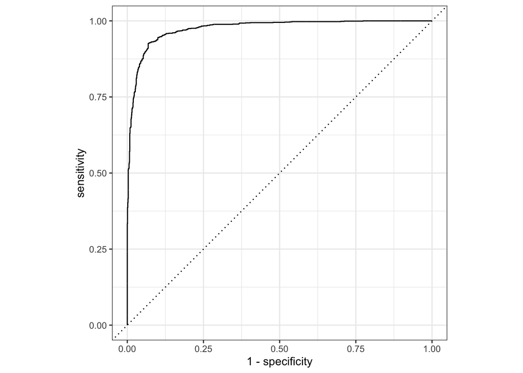

```r
s_repens_predict1 <- s_repens_test_df %>%
  mutate(predict(blr1_fit, new_data = s_repens_test_df)) %>%
  mutate(predict(blr1_fit, new_data = ., type = 'prob'))

s_repens_predict2 <- s_repens_test_df %>%
  mutate(predict(blr2_fit, new_data = s_repens_test_df)) %>%
  mutate(predict(blr2_fit, new_data = ., type = 'prob'))


roc1_df <- roc_curve(s_repens_predict1, truth = s_repens, .pred_0)
autoplot(roc1_df)
```

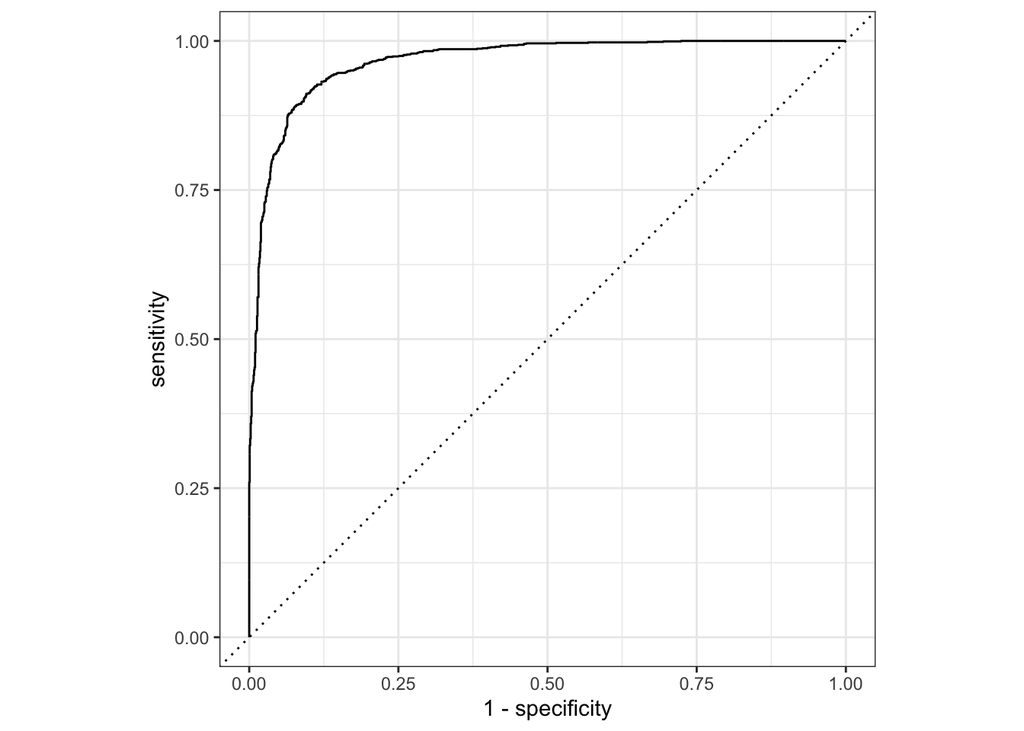

```r
roc2_df <- roc_curve(s_repens_predict2, truth = s_repens, .pred_0)
autoplot(roc2_df)
```

It seems like the first model does a slightly better job at predicting whether a Palmetto is S. repens given the larger area under the curve. The AIC score is also lower for model 1, so I would say that this is the best model overall.

## 1.4 Training the selected model

Split the data into portions for building and comparing models (80%) and for testing the models (20%)

```r
palmetto_clean %>%
  group_by(s_repens) %>%
  summarize(n = n()) %>%
  ungroup() %>%
  mutate(prop = n / sum(n))
```

```
# A tibble: 2 × 3
  s_repens     n  prop
  <fct>    <int> <dbl>
1 0         6155 0.502
2 1         6112 0.498
```

```r
#convert s_repens to factor
palmetto_clean <- palmetto_clean %>%
  mutate(s_repens = as.factor(s_repens))

#split into 80% and 20%
set.seed(123)
s_repens_split <- initial_split(palmetto_clean, prop = 0.80, strata = s_repens)
  ### stratified on `s_repens`
s_repens_train_df <- training(s_repens_split)
s_repens_test_df <- testing(s_repens_split)
```

```r
blr1_fit
```

```
parsnip model object


Call:  stats::glm(formula = s_repens ~ height + length + width + green_lvs,
    family = stats::binomial, data = data)

Coefficients:
(Intercept)       height       length        width    green_lvs
   -3.18799      0.02899     -0.04528     -0.03993      1.90743

Degrees of Freedom: 9812 Total (i.e. Null);  9808 Residual
Null Deviance:      13600
Residual Deviance: 4181     AIC: 4191
```

### 1.4.1 BLR table

```r
blr1_tidy <- broom::tidy(blr1_fit)
knitr::kable(blr1_tidy)
```

| term | estimate | std.error | statistic | p.value |
| --- | --- | --- | --- | --- |
| (Intercept) | -3.1879858 | 0.1578943 | -20.19064 | 0 |
| height | 0.0289911 | 0.0025808 | 11.23332 | 0 |
| length | -0.0452761 | 0.0020500 | -22.08559 | 0 |
| width | -0.0399315 | 0.0023153 | -17.24677 | 0 |
| green_lvs | 1.9074294 | 0.0433752 | 43.97514 | 0 |

## 1.5 How well does the above model predict if a Palmetto is S. repens?

We’ll use our fitted model from the training set on the test set to see how the predictions compare.

```r
#using 50% probability threshold
s_repens_predict1 <- s_repens_test_df %>%
  mutate(predict(blr1_fit, new_data = s_repens_test_df)) %>%
  mutate(predict(blr1_fit, new_data = ., type = 'prob'))
```

```r
df1 <- as.data.frame(table(s_repens_predict1 %>%
        select(s_repens, .pred_class)))

df1 <- df1 %>%
  mutate(s_repens = as.numeric(s_repens)) %>%
  mutate(.pred_class = as.numeric(.pred_class)) %>%
  mutate(pred = (s_repens + .pred_class)) %>%
  mutate(pred = as.character(pred)) %>%
  mutate(Species = as.character(s_repens)) %>%
  mutate(prediction = case_when(
    endsWith(pred,"3") ~ "Failed",
    endsWith(pred, "2") ~ "Succeeded",
    endsWith(pred, "4") ~ "Succeeded")) %>%
  mutate(Species = gsub("2","s_repens", Species)) %>%
  mutate(Species = gsub("1","s_etonia", Species)) %>%
  select(Freq, prediction, Species) %>%
  pivot_wider(names_from = prediction, values_from = Freq) %>%
  mutate("% correctly classified" = Succeeded/(Succeeded + Failed)*100)

knitr::kable(df1)
```

| Species | Succeeded | Failed | % correctly classified |
| --- | --- | --- | --- |
| s_etonia | 1132 | 99 | 91.95776 |
| s_repens | 1139 | 84 | 93.13164 |

The model classified both species with a pretty high success rate, with less than 10% of trees incorrectly classified for each group. The model did a slightly better job classifying S. repens than it did S. etonia, but this model seems to be fairly balanced overall.